- Group Information
- Peak Calling Statistics
- Annotation of Peaks

# Azenta ChIP-seq Group Report

## 1. Group Information

| Customer | Anders Ohman |
| --- | --- |
| Email | anders_ohman@brown.edu |
| QuoteNumber | 30-858293328 |
| Configuration |  |
| Group | I |

## 2. Peak Calling Statistics

MACS2 2.1.2 was used to call peaks for each sample in group I. Called peaks were merged within each group and peaks called in at least 3 samples were kept for downstream analysis.

| Sample | Number of Peaks |
| --- | --- |
| TA1-2m1 | 302 |
| TA1-2m3 | 1456 |
| TA1-3m1 | 906 |
| TA1-3m2 | 1254 |
| Merged | 10 |

## 3. Peak Annotation

[figure not shown]

### 3.2 Peak annotation by genomic feature

Peaks were annotated based on the genomic features they overlap. When annotations overlap assignment priorities are: Promoter > 5’UTR > 3’UTR > Exon > Intron > Downstream > Intergenic.

Figure 3.2 Composition of peak overlaps with annotated genomic features

[figure not shown]

Figure 3.2 Composition of annotated peaks

Figure 3.3 Histogram of overlapping features under merged peaks, ranked by the number of peaks.

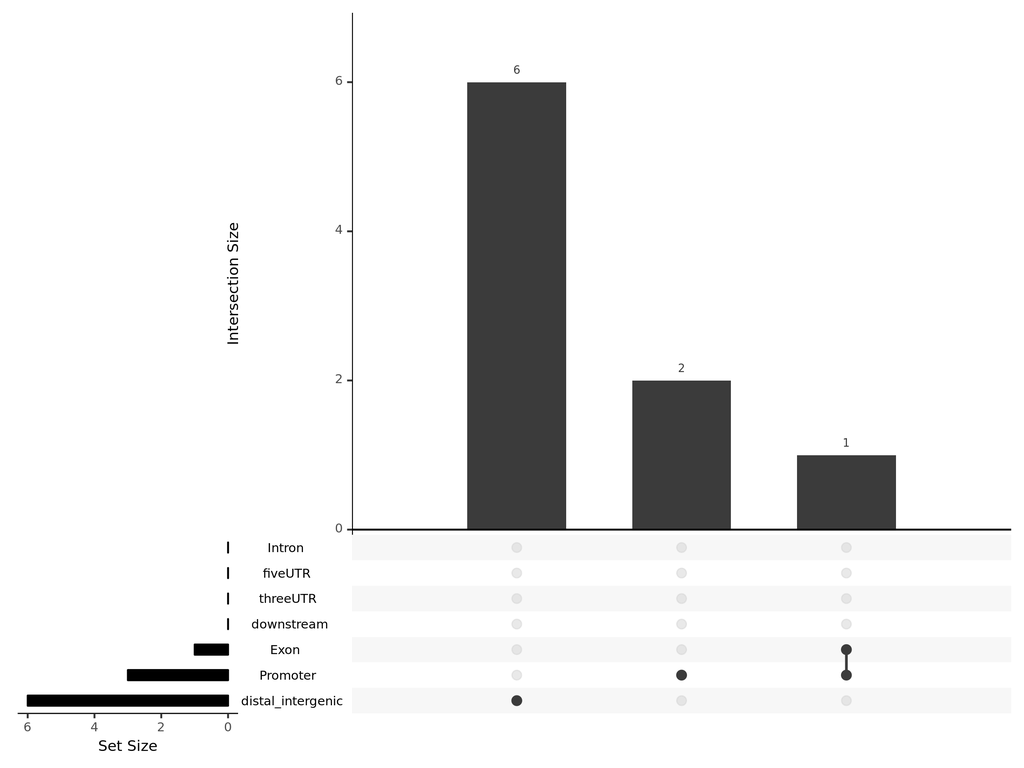

Figure 3.3 Overlapping genomic features by peak count

Figure 3.4 Distribution of genomic distances from peak summits to the nearest TSS.

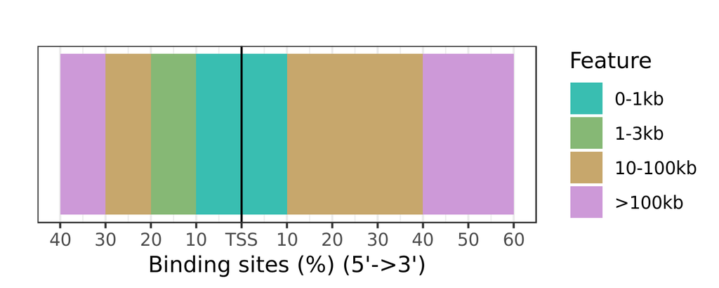

Figure 3.4 Distribution of genomic distance from peak summits to the nearest TSS

Table 3.1 First 100 peaks from the annotated peaks table.

| chr | start | end | strand | annotation | geneStart | geneEnd | geneStrand | geneId | transcriptId | distanceToTSS | gene_symbol | gene_name | gene_biotype | description |
| --- | --- | --- | --- | --- | --- | --- | --- | --- | --- | --- | --- | --- | --- | --- |
| 12 | 9562683 | 9563061 | * | Distal Intergenic | 9597063 | 9597191 | 1 | ENSRNOG00000053421 | ENSRNOT00000086197 | -34002 |  | ENSRNOG00000053421 | snoRNA | predicted gene, 24556 [Source:MGI Symbol;Acc:MGI:5454333] |
| 14 | 46643717 | 46645178 | * | Promoter (&lt;=1kb) | 46646166 | 46646318 | 1 | ENSRNOG00000059852 | ENSRNOT00000085643 | -988 | Rn5-8s | Rn5-8s | rRNA | 5.8S ribosomal RNA [Source:RGD Symbol;Acc:5687331] |
| 15 | 67374835 | 67375245 | * | Distal Intergenic | 67555835 | 67645088 | 1 | ENSRNOG00000008970 | ENSRNOT00000045882 | -180590 | Pcdh17 | Pcdh17 | protein_coding | protocadherin 17 [Source:RGD Symbol;Acc:1304753] |
| 17 | 26620212 | 26620653 | * | Distal Intergenic | 26541235 | 26541475 | 1 | ENSRNOG00000060377 | ENSRNOT00000086528 | 78977 |  | 7SK | misc_RNA | 7SK RNA [Source:RFAM;Acc:RF00100] |
| 19 | 56337808 | 56338790 | * | Promoter (&lt;=1kb) | 56338736 | 56338854 | 2 | ENSRNOG00000055067 | ENSRNOT00000072497 | 64 |  | 5S_rRNA | rRNA | 5S ribosomal RNA [Source:RFAM;Acc:RF00001] |
| 2 | 64996929 | 64997382 | * | Distal Intergenic | 65010320 | 65011966 | 2 | ENSRNOG00000058937 | ENSRNOT00000081901 | 14584 |  | AABR07008568.1 | lincRNA |  |
| 20 | 27119466 | 27119957 | * | Promoter (1-2kb) | 27103317 | 27117663 | 2 | ENSRNOG00000000386 | ENSRNOT00000000434 | -1803 | Pbld1 | Pbld1 | protein_coding | phenazine biosynthesis-like protein domain containing 1 [Source:RGD Symbol;Acc:621263] |
| 20 | 40913519 | 40913935 | * | Distal Intergenic | 41021732 | 41028761 | 2 | ENSRNOG00000054949 | ENSRNOT00000077252 | 114826 |  | AABR07072837.1 | lincRNA |  |
| 4 | 48456579 | 48456933 | * | Distal Intergenic | 48852827 | 48928372 | 2 | ENSRNOG00000059016 | ENSRNOT00000083938 | 471439 | Tspan12 | Tspan12 | protein_coding | tetraspanin 12 [Source:RGD Symbol;Acc:1311102] |
| 4 | 77410268 | 77410848 | * | Downstream (2-3kb) | 77385900 | 77385977 | 1 | ENSRNOG00000061624 | ENSRNOT00000090030 | 24368 |  | Y_RNA | misc_RNA | Y RNA [Source:RFAM;Acc:RF00019] |

- Azenta Life Sciences
- Next Generation Sequencing
- Email: ngs@azenta.com
- Phone: 908-222-0711 ext 1